# Stat400 Project 3

Example code:

```r
#This is a small demonstration of the command replicate(). It replicates drawing a sample of size 15, 10 times from a normal distribution with mean 10 and variance 1. As you can see from the output, the samples appear along the columns as the repetitions appear along the columns.

set.seed(1)
samples <- replicate(10, rnorm(15, 10, 1))
samples
```

```
##            [,1]      [,2]      [,3]      [,4]      [,5]      [,6]      [,7]
##  [1,]  9.373546  9.955066 11.358680  9.292505 12.401618 10.291446  9.457480
##  [2,] 10.183643  9.983810  9.897212 10.364582  9.960760  9.556708 11.207868
##  [3,]  9.164371 10.943836 10.387672 10.768533 10.689739 10.001105 11.160403
##  [4,] 11.595281 10.821221  9.946195  9.887654 10.028002 10.074341 10.700214
##  [5,] 10.329508 10.593901  8.622940 10.881108  9.256727  9.410479 11.586833
##  [6,]  9.179532 10.918977  9.585005 10.398106 10.188792  9.431331 10.558486
##  [7,] 10.487429 10.782136  9.605710  9.387974  8.195041  9.864821  8.723408
##  [8,] 10.738325 10.074565  9.940687 10.341120 11.465555 11.178087  9.426735
##  [9,] 10.575781  8.010648 11.100025  8.870637 10.153253  8.476433  8.775387
## [10,]  9.694612 10.619826 10.763176 11.433024 12.172612 10.593946  9.526599
## [11,] 11.511781  9.943871  9.835476 11.980400 10.475510 10.332950  9.379633
## [12,] 10.389843  9.844204  9.746638  9.632779  9.290054 11.063100 10.042116
## [13,]  9.378759  8.529248 10.696963  8.955865 10.610726  9.695816  9.089078
## [14,]  7.785300  9.521850 10.556663 10.569720  9.065902 10.370019 10.158029
```

[output cut: 17 more lines]

```r
#We can cycle through the columns and calculate the average of each column as follows by looping through with a for loop.

for(i in 1:10) {
    cat(mean(samples[,i]), "is the average for column", i, "\n")
}
```

```
## 10.10084 is the average for column 1
## 10.06407 is the average for column 2
## 10.09029 is the average for column 3
## 10.17526 is the average for column 4
## 10.18004 is the average for column 5
## 10.04051 is the average for column 6
## 9.942512 is the average for column 7
## 10.28415 is the average for column 8
## 9.915281 is the average for column 9
## 9.424663 is the average for column 10
```

```r
set.seed(1)
samples <- replicate(1000, rnorm(40, 10, 1)) #replicates drawing a sample of size 40, 1000 times from a normal distribution with mean 10 and variance 1
sample_mean <- 1:1000 #creates vector of length 1000 where sample_mean[i]=i
for(i in 1:1000) {
    sample_mean[i] <- mean(samples[,i]) #sets each sample_mean[i] to be the mean of the ith sample
}

#Empirical verification of unbiasedness
mean(sample_mean) #suggests E(X-bar)=u since this value is very close to u=10
```

```
## [1] 9.99782
```

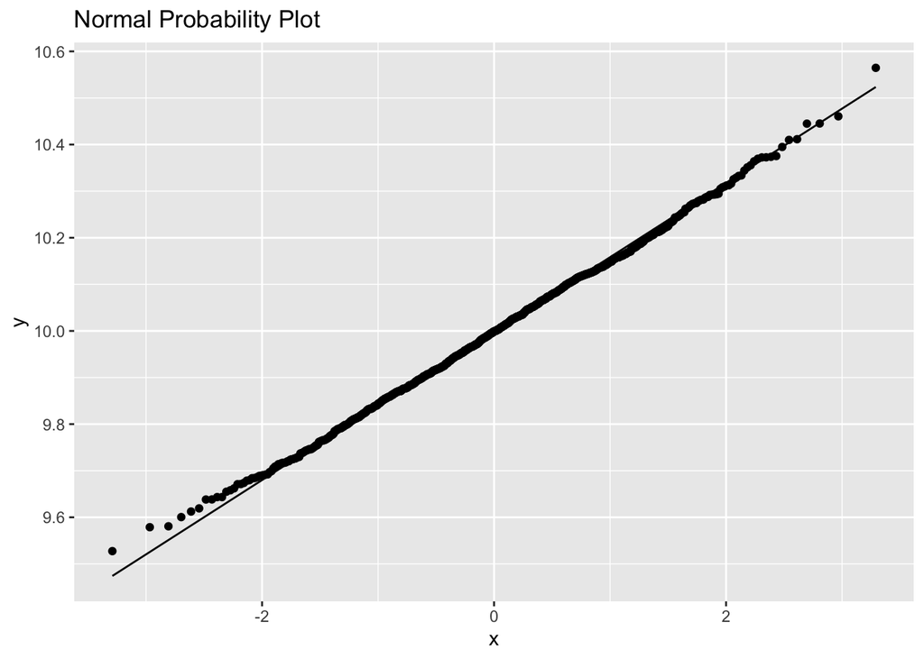

```r
#Normality plot
library(ggplot2)
#Create the normal probability plot
ggplot(data.frame(sample_mean), aes(sample = sample_mean)) +
stat_qq() + #creates a Q-Q plot, comparing the sample means to the values of a true normal distribution
stat_qq_line() +
labs(title = "Normal Probability Plot")
```

### Project Starts Here

Note my UID is 119718025 so I set all seeds to 25

1.) (An empirical verification of the Central Limit Theorem for uniform distributions): Simulate drawing samples of size 40 from a uniform distribution on [0,1] a total of 1000 times. Compute the average of each sample (resulting in 1000 values). Draw a normality plot (see chapter 4.6 of the textbook). Is it reasonable to say that the averages are normally distributed? Repeat this exercise with the sample size from the uniform distribution set to 2. Repeat this problem with an exponential distribution with λ=4.

```r
set.seed(25)
unifsamples <- replicate(1000, runif(40, 0, 1))
unifmeans <- 1:1000
for(i in 1:1000) {
    unifmeans[i] <- mean(unifsamples[,i])
}
mean(unifmeans)
```

```
## [1] 0.4992551
```

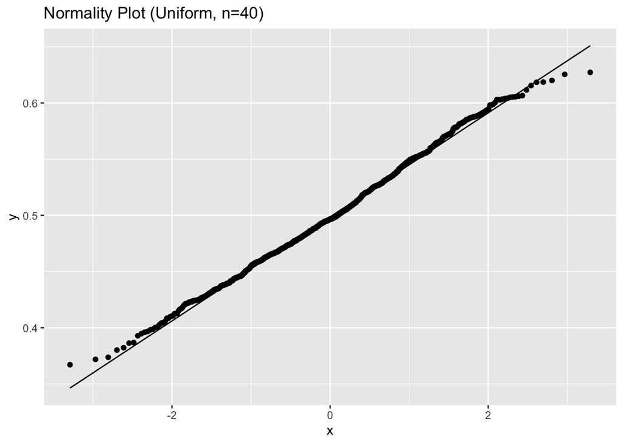

```r
ggplot(data.frame(unifmeans), aes(sample = unifmeans)) +
stat_qq() +
stat_qq_line() +
labs(title = "Normality Plot (Uniform, n=40)")
```

According to the textbook (pg 187), “If the sample observations are in fact drawn from a normal distribution with mean value mu and standard deviation σ, the points should fall close to a straight line with slope σ and intercept mu. Thus a plot for which the points fall close to some straight line suggests that the assumption of a normal population distribution is plausible.” In this case, the dots corresponding to the sample means line up very closely with the line, which represents the values we would get from a truly normal distribution. Given the strong resemblance of the sample means to a straight line, it is reasonable to say that the averages are normally distributed for n=40. Now let’s repeat this with n=2.

```r
set.seed(25)
unifsamples2 <- replicate(1000, runif(2, 0, 1))
unifmeans2 <- 1:1000
for(i in 1:1000) {
    unifmeans2[i] <- mean(unifsamples2[,i])
}
mean(unifmeans2)
```

```
## [1] 0.5089595
```

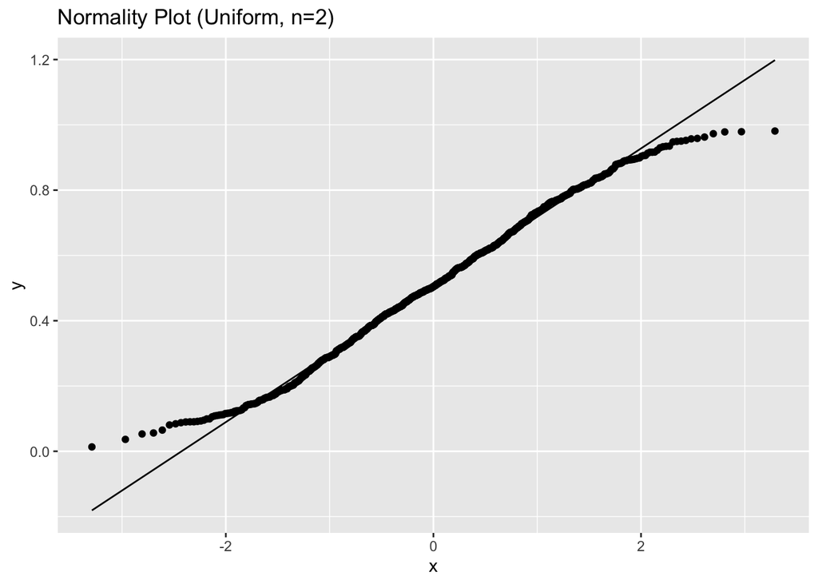

```r
ggplot(data.frame(unifmeans2), aes(sample = unifmeans2)) +
stat_qq() +
stat_qq_line() +
labs(title = "Normality Plot (Uniform, n=2)")
```

When we change the sample size to n=2, we do not see the dots form a straight line, but instead more of an S-shape that corresponds to a light-tailed distribution. What this means is that sample means that are far from the true mean of 0.5 occur at a lower rate than we would expect under a truly normal distribution. This is because the sample mean cannot possibly be less than 0 or greater than 1 for this distribution, yielding an asymptote at y=0 as we move left along the x-axis, and an asymptote at y=1 as we move right. Given the resemblance of the sample means to an S-shape rather than a straight line, it is not reasonable to say that the averages are normally distributed for n=2. We’ll now repeat this problem for an exponential distribution with λ=4.

```r
set.seed(25)
expsamples <- replicate(1000, rexp(40, 4))
expmeans <- 1:1000
for(i in 1:1000) {
    expmeans[i] <- mean(expsamples[,i])
}
mean(expmeans)
```

```
## [1] 0.2499256
```

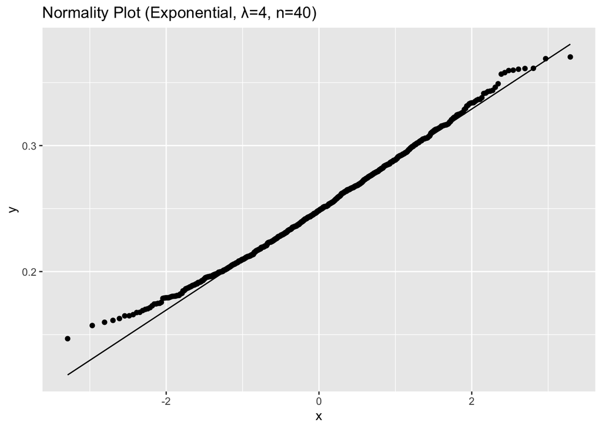

```r
ggplot(data.frame(expmeans), aes(sample = expmeans)) +
stat_qq() +
stat_qq_line() +
labs(title = "Normality Plot (Exponential, λ=4, n=40)")
```

For the exponential distribution with λ=4 and n=40, we see a similar trend to what we saw for the uniform distribution with n=40. The dots do seem to stray from the line at the lower end because the sample mean cannot possibly be less than 0 for an exponential distribution, yielding an asymptote at y=0 as we move left along the x-axis. However, the dots resemble a straight enough line that it is reasonable to say that the averages are normally distributed for n=40. Once again we do the same thing for n=2.

```r
set.seed(25)
expsamples2 <- replicate(1000, rexp(2, 4))
expmeans2 <- 1:1000
for(i in 1:1000) {
    expmeans2[i] <- mean(expsamples2[,i])
}
mean(expmeans2)
```

```
## [1] 0.2445439
```

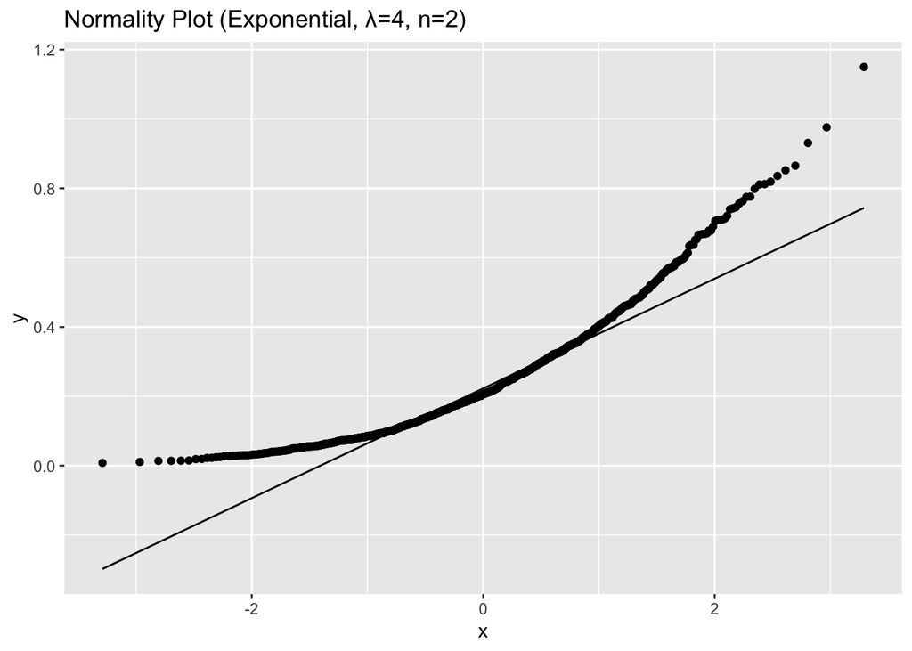

```r
ggplot(data.frame(expmeans2), aes(sample = expmeans2)) +
stat_qq() +
stat_qq_line() +
labs(title = "Normality Plot (Exponential, λ=4, n=2)")
```

When we reduce the sample size to n=2, the dots no longer resemble a straight line, but more of a U-shape, similar to the positively skewed distribution in the textbook (pg 189). Looking at the upper end, this means that sample means that are far above the true mean of 1/4 occur at a higher rate than we would expect under a truly normal distribution. Looking at the lower end, this means sample means that are far below the true mean occur at a lower rate than we would expect under a normal distribution. This is because the sample mean of an exponential distribution can never take on a negative value, so there is an asymptote at y=0 as we move left along the x-axis. Considering the resemblance of the sample means to a U-shape rather than a straight line, it is not reasonable to say that the averages are normally distributed for n=2.

2.) (Normality plot from scratch): In the code that I have provided, I used a built-in function for drawing normality plots, completely bypassing the need to use the equations mentioned in chapter 4.6 of the textbook. Repeat exercise 1 that does not use a built-in function that directly draws a normality plot but does use a function that you have written down for this purpose. Hint: The order() function may be of use here.

According to the textbook (pg 187), “A plot of the n pairs ([100(i-0.5)/n]th z percentile, ith smallest observation) is called a normal probability plot.” So to make this plot by hand, I need to sort the sample means from least to greatest, get the z percentile corresponding to each sample mean, then plot them.

```
## 0.4992551
```

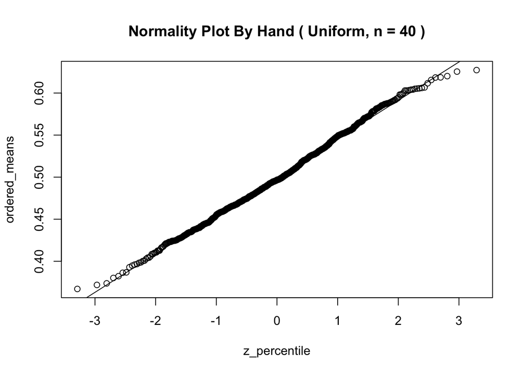

```r
unif_normality_plot <- function(lower, upper, sample_size, replications) {
  set.seed(25)
  samples <- replicate(replications, runif(sample_size, lower, upper))
  means <- 1:replications
  z_percentile <- 1:replications
  for(i in 1:replications) {
    means[i] <- mean(samples[,i])
    z_percentile[i] <- qnorm((i-0.5)/replications)
  }
  cat(mean(means), "\n")
  ordered_means <- sort(means)
  plot(z_percentile, ordered_means, main=paste("Normality Plot By Hand ( Uniform, n =", sample_size, ")"))
  abline((upper-lower)/2, (upper-lower)/sqrt(12)/sqrt(sample_size))
  #Using mu+σ(z-quantile), where mu=E(X-bar)=E(Xi)=(b-a)/2, σ=√(Var(X-bar))=√(Var(Xi)/n)=(b-a)/√12/√n
}
unif_normality_plot(0, 1, 40, 1000)
```

```
## 0.5089595
```

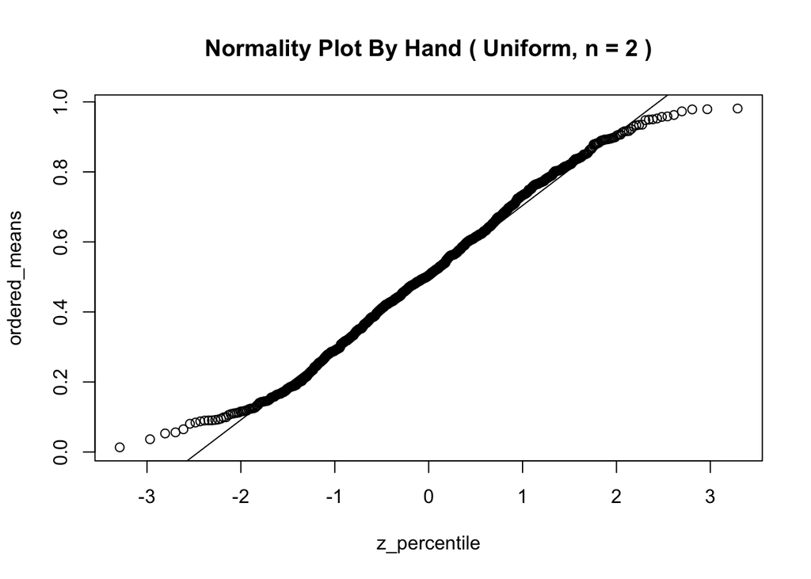

```r
unif_normality_plot(0, 1, 2, 1000)
```

```
## 0.2499256
```

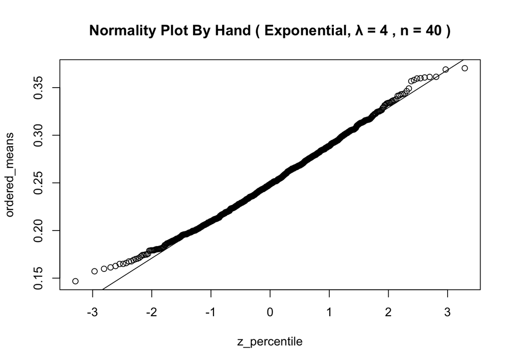

```r
exp_normality_plot <- function(lambda, sample_size, replications) {
  set.seed(25)
  samples <- replicate(replications, rexp(sample_size, lambda))
  means <- 1:replications
  z_percentile <- 1:replications
  for(i in 1:replications) {
    means[i] <- mean(samples[,i])
    z_percentile[i] <- qnorm((i-0.5)/replications)
  }
  cat(mean(means), "\n")
  ordered_means <- sort(means)
  plot(z_percentile, ordered_means, main=paste("Normality Plot By Hand ( Exponential, λ =", lambda, ", n =", sample_size, ")"))
  abline(1/lambda, 1/lambda/sqrt(sample_size))
  #Using mu+σ(z-quantile) from textbook, where mu=E(X-bar)=E(Xi)=1/λ, σ=√(Var(X-bar))=√(Var(Xi)/n)=√(1/λ^2)/√n=(1/λ)/√n
}
exp_normality_plot(4, 40, 1000)
```

```
## 0.2445439
```

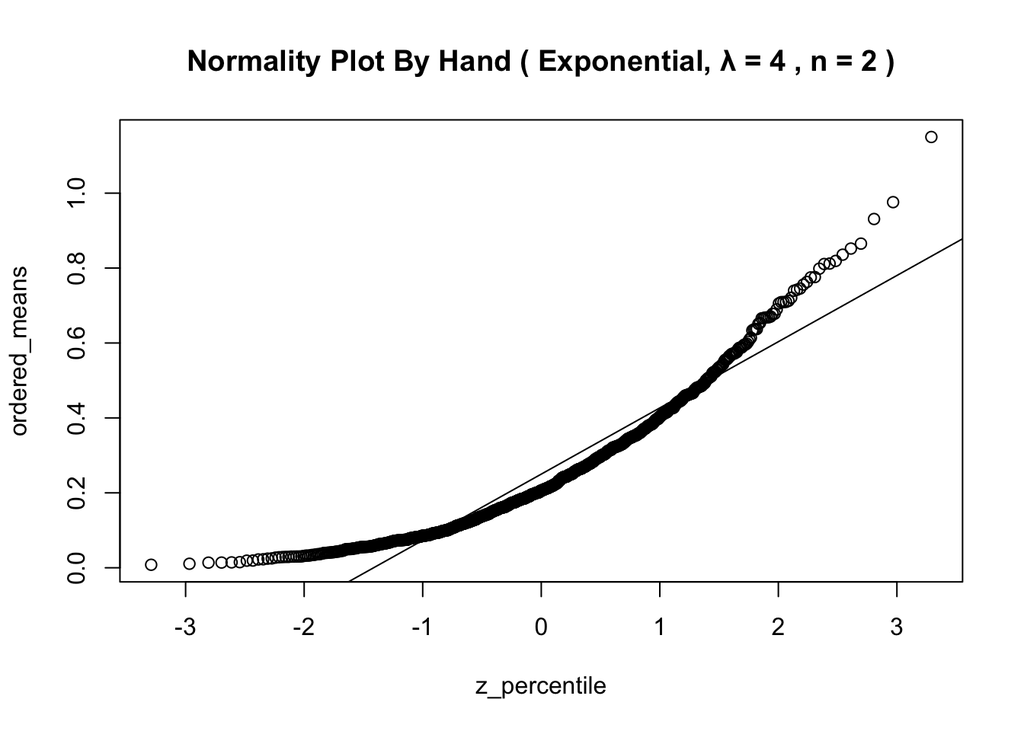

```r
exp_normality_plot(4, 2, 1000)
```

3i.) Attached as submission comment in ELMS

3ii.) Generate a sample of size 4000 from a normal distribution with mu=2, σ^2=5 and use it to compute the maximum likelihood estimates for mu and σ^2.

```r
set.seed(25)
sample <- rnorm(4000, 2, sqrt(5))
mu_hat <- sum(sample)/4000
sigmasquared_hat <- sum((sample-mean(sample))^2)/4000
mu_hat #MLE for mu
```

```
## [1] 2.007491
```

```r
sigmasquared_hat #MLE for σ^2
```

```
## [1] 5.031892
```

4.) (Confidence Intervals 1): Simulate drawing 10000 samples each of size 50 from an exponential distribution with λ=2. For each sample, construct a 99% confidence interval for the mean and check to see whether theoretical value for the mean is included in the confidence interval. Determine the proportion of confidence intervals that contain the expected value. Explain how this does/does not fit in with your theoretical understanding of what a confidence interval is.

```r
set.seed(25)
exp_samples <- replicate(10000, rexp(50, 2))
z <- qnorm(0.995) #since a=1-0.99=0.01, z-score is the 99.5th percentile of a standard normal distribution
count <- 0
for(i in 1:10000) {
  mean <- mean(exp_samples[,i])
  sd <- sd(exp_samples[,i])
  lowerbound <- mean - z*(sd/sqrt(50))
  upperbound <- mean + z*(sd/sqrt(50))
  if(lowerbound <= 1/2 & 1/2 <= upperbound) {
    count <- count+1 #counts number of intervals that capture true mean of 1/λ=1/2
  }
}
count
```

```
## [1] 9737
```

```r
count/10000
```

```
## [1] 0.9737
```

Out of the 10000 constructed confidence intervals, 9737 of them captured the true mean value of 1/2, which is 97.37%. Our theoretical understanding of confidence intervals tells us that the confidence level, in this case 99%, represents the proportion of the confidence intervals that capture the true mean as the number of confidence intervals we construct, each from a different random sample, approaches infinity. We can see that 97.37% of the confidence intervals constructed in this experiment capture the true mean of 1/2, which is close to 99%, but not exact. Part of the reason this figure is not exactly 99% is because the number of confidence intervals we constructed, 10000, is finite. Another reason is that even with 10000 samples, sampling variation can occur simply by chance, especially with a sample size of just 50. A third reason is that (x-bar - mu / s/√n) ~ N(0,1) is only an approximation using the Central Limit Theorem, so we should not expect that exactly 99% of our confidence intervals capture the true mean.

5.) (Confidence Intervals 2): Load the built-in iris data set. Split the data based on Species. Create a confidence interval for Petal.Length for each species. As a comment you should include if you are using CLT or not and why.

```r
data("iris")
iris
```

| Sepal.Length | Sepal.Width | Petal.Length | Petal.Width | Species |
| --- | --- | --- | --- | --- |
| 5.1 | 3.5 | 1.4 | 0.2 | setosa |
| 4.9 | 3.0 | 1.4 | 0.2 | setosa |
| 4.7 | 3.2 | 1.3 | 0.2 | setosa |
| 4.6 | 3.1 | 1.5 | 0.2 | setosa |
| 5.0 | 3.6 | 1.4 | 0.2 | setosa |
| 5.4 | 3.9 | 1.7 | 0.4 | setosa |
| 4.6 | 3.4 | 1.4 | 0.3 | setosa |
| 5.0 | 3.4 | 1.5 | 0.2 | setosa |
| 4.4 | 2.9 | 1.4 | 0.2 | setosa |
| 4.9 | 3.1 | 1.5 | 0.1 | setosa |

[output cut: 140 more lines]

```r
setosa <- iris[1:50,]
versicolor <- iris[51:100,]
virginica <- iris[101:150,]

#We can use the central limit theorem here since we have exactly 50 of each species of flower, meaning the sample size for each species is 50, which is greater than 30. Since n>30 is our general requirement for usage of CLT, we are able to use it here.

z <- qnorm(0.975) #if we're constructing a 95% confidence interval, a=1-0.95=0.05, so z-score is the 97.5th percentile of a standard normal distribution

setosa_mean <- mean(setosa[,3])
setosa_sd <- sd(setosa[,3])
setosa_lower <- setosa_mean - z*(setosa_sd/sqrt(50))
setosa_upper <- setosa_mean + z*(setosa_sd/sqrt(50))
cat("95% confidence interval for mean petal length of setosa species: (", setosa_lower, ",", setosa_upper, ")\n")
```

```
## 95% confidence interval for mean petal length of setosa species: ( 1.413864 , 1.510136 )
```

```r
versi_mean <- mean(versicolor[,3])
versi_sd <- sd(versicolor[,3])
versi_lower <- versi_mean - z*(versi_sd/sqrt(50))
versi_upper <- versi_mean + z*(versi_sd/sqrt(50))
cat("95% confidence interval for mean petal length of versicolor species: (", versi_lower, ",", versi_upper, ")\n")
```

```
## 95% confidence interval for mean petal length of versicolor species: ( 4.12975 , 4.39025 )
```

```r
virg_mean <- mean(virginica[,3])
virg_sd <- sd(virginica[,3])
virg_lower <- virg_mean - z*(virg_sd/sqrt(50))
virg_upper <- virg_mean + z*(virg_sd/sqrt(50))
cat("95% confidence interval for mean petal length of virginica species: (", virg_lower, ",", virg_upper, ")\n")
```

```
## 95% confidence interval for mean petal length of virginica species: ( 5.399025 , 5.704975 )
```